# Multiple Logistic Regression Example

# Problem Statement

The Corporate Average Fuel Economy (CAFE) bill was proposed by Senators John McCain and John Kerry to improve the fuel economy of cars and light trucks sold in the United States. However, a critical vote on an amendment in March 2002 threatened to indefinitely postpone CAFE. It passed by a vote of 62-38.

A political question of interest is whether there is evidence of monetary influence on a senator’s vote. Scott Preston, a professor of statistics at SUNY, Oswego, collected data on this vote, which includes our response variable, the vote of each senator (Yes or No), and as an explanatory variable, monetary contributions that each of the 100 senators received over his or her lifetime from car manufacturers.

Anyone with an interest in U.S. politics might naturally be led to ask the following questions:

- Including contributions in the model, what is the effect of party affiliation on the vote?
- Including party in the model, what is the effect of increased contributions on the vote? (Tweaked a bit from Cannon et al. 2013 [Chapter 10])

# Competing Hypotheses

The model corresponds to the log odds of a Yes vote as the response and `LogContr = log(Contribution + 1)` and `Party` as the explanatory variables:
$$\log \left(
\frac{p}{1-p} \right) = \beta_0 + \beta_1 LogContr + \beta_2
Party.$$
(Senator James Jeffords of Vermont, an Independent who caucused with the Democrats, has had his `Party` changed from `I` to `D` so the variable is dichotomous.)

## In words

- Null hypothesis: The coefficients of the logistic regression modeling log(odds) of Vote as a function of log contribution and party are zero.
- Alternative hypothesis: At least one of the coefficients of the logistic regression modeling log(odds) of Vote as a function of log contribution and party is nonzero.

## In symbols (with annotations)

- $H_0: \beta_i = 0$, where $\beta_i$ represents the population coefficient on the parameters of the logistic regression modeling log(odds) of Vote as a function of log contribution and party.
- $H_A:$ At least one $\beta_i \ne 0$

## Set $\alpha$

It’s important to set the significance level before starting the testing using the data. Let’s set the significance level at 5% here.

# Exploring the sample data

```r
data(CAFE)
cafe <- CAFE |>
  mutate(Party = sub(pattern = "I", replacement = "D", x = Party, fixed = TRUE),
         Party = as.character(Party)) |>
  select(-Dem)
```

The plot below shows the relationship between log contributions, vote, and party.

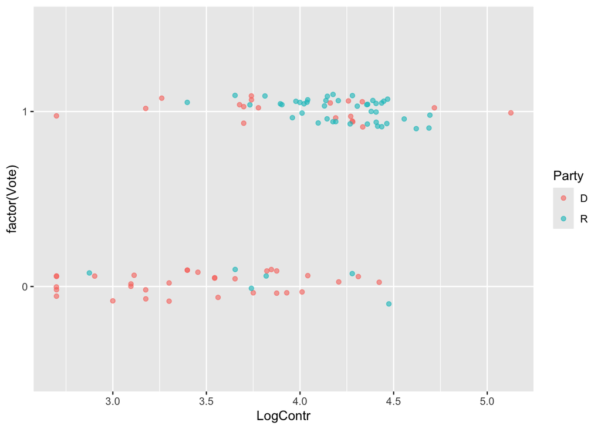

```r
cafe |> ggplot(aes(x = LogContr, y = factor(Vote), color = Party)) +
  geom_jitter(height = 0.1, alpha = 0.6)
```

## Guess about statistical significance

It seems that party affiliation and whether a Senator voted “yes” are related. There are far fewer Republicans that voted against the bill than Democrats. There also appears to be a relationship between contributions and voting “yes”.

# Non-traditional methods

We’ll use **`infer`**’s `fit()` function. Because the response is a two-level factor, `infer` fits a **logistic regression** via `glm()`. Permuting the response and refitting gives a null distribution for each coefficient.

## Observed coefficients

```r
obs_fit <- cafe |>
  mutate(Vote = factor(Vote)) |>
  specify(Vote ~ LogContr + Party) |>
  fit()
obs_fit
```

```
## # A tibble: 3 × 2
##   term      estimate
##   <chr>        <dbl>
## 1 intercept    -8.57
## 2 LogContr      2.17
## 3 PartyR        1.73
```

## Randomization for Hypothesis Test

Under the null of no association, the `Vote` values are exchangeable, so `infer` shuffles the response with `hypothesize(null = "independence")`, refits the logistic model, and records each coefficient 1,000 times.

```r
set.seed(2018)
null_fits <- cafe |>
  mutate(Vote = factor(Vote)) |>
  specify(Vote ~ LogContr + Party) |>
  hypothesize(null = "independence") |>
  generate(reps = 1000, type = "permute") |>
  fit()
```

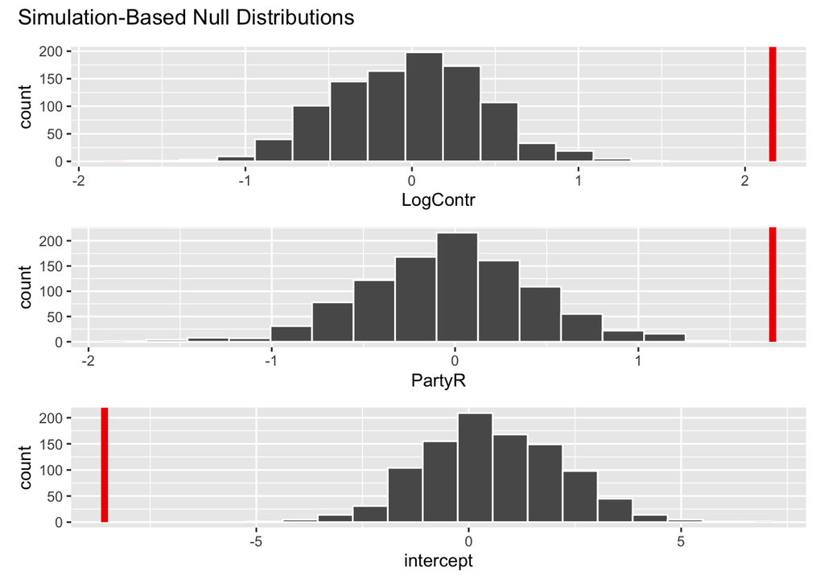

```r
visualize(null_fits) +
  shade_p_value(obs_stat = obs_fit, direction = "both")
```

### Calculate $p$-values

```r
get_p_value(null_fits, obs_stat = obs_fit, direction = "both")
```

```
## # A tibble: 3 × 2
##   term      p_value
##   <chr>       <dbl>
## 1 LogContr        0
## 2 PartyR          0
## 3 intercept       0
```

The permutation-based $p$-values flag the same terms as important as the theory-based test below.

# Traditional methods

## Check conditions

The key conditions are a linear relationship on the logit scale and independent observations.

1. *Linear relationship on the logit scale*: This condition is difficult to check without binning the data and computing the empirical logit function. We will assume that this condition is met here.
2. *Independent observations*: What matters is the *conditional* version of the question: if two senators belong to the same party and receive the same campaign amounts, are their votes independent? Senators from the same state tend to vote the same way more often than the independence condition predicts (observed 38 states voting together vs. about 31 expected under independence), which calls the condition into question. We proceed with inference but regard the results as tentative guidelines.

## Test statistic

We estimate each population coefficient $\beta_i$ with the sample coefficient $B_i$. If the conditions are met and assuming $H_0$ is true, we can standardize each $B_i$ into a $Z$ statistic that follows a $N(0, 1)$ distribution:

$$Z =\dfrac{ B_i - 0}{ {SE}_i } \sim N(0,
1)$$

## Observed test statistic

We use the `glm` function with `family = binomial` to fit the model, summarizing the output with `moderndive`’s `get_regression_table()`.

```r
cafe_glm <- glm(Vote ~ LogContr + Party, family = binomial, data = cafe)
get_regression_table(cafe_glm)
```

```
## # A tibble: 3 × 7
##   term      estimate std_error statistic p_value lower_ci upper_ci
##   <chr>        <dbl>     <dbl>     <dbl>   <dbl>    <dbl>    <dbl>
## 1 intercept    -8.57     2.34      -3.66   0      -13.6      -4.36
## 2 LogContr      2.17     0.613      3.53   0        1.06      3.49
## 3 Party-R       1.73     0.58       2.98   0.003    0.624     2.93
```

The sign on `LogContr` is positive, corresponding to a positive relationship between voting “yes” and contributions (holding party fixed). The sign on `Party-R` (relative to the `D` baseline) is also positive, agreeing with our intuition that Republicans are more likely to vote “yes” than Democrats.

# Compute $p$-values

From the regression table, the `intercept`, `LogContr`, and `Party-R` terms are statistically significant at the 5% level. This agrees with the simulation-based $p$-values above.

# State conclusion

We, therefore, have sufficient evidence to reject the null hypothesis for `LogContr` and on `Party`, assuming the other term is in the model. Our initial guess that the variables would be related to a “Yes” vote is validated by our statistical analyses here.

# Comparing results

The simulation-based (`infer::fit()` permutation) and theory-based (`glm()` + `get_regression_table()`) approaches flag the same coefficients as important. Given the questionable independence condition, we treat both sets of results as tentative guidelines rather than definitive conclusions.

Cannon, Ann R., George W. Cobb, Bradley A. Hartlaub, et al. 2013. *STAT2 - Building Models for a World of Data*.